# Práctica 3 - Análisis de Riesgo

Práctica 3 - Análisis de Riesgo Carlos K. Delgado 17/6/2018

## Modelo de predicción de riesgo de crédito para el año 2018 (12 meses).

### Lectura y unión de las bases de datos

```r
## Cargamos el directorio
setwd("~/Desktop/Máster en Big Data/Análisis del Riesgo de Crédito/Prueba 3")

## Lectura de los datos

#coste_mercancias <- read.table("coste_mercaderias.txt", stringsAsFactors = FALSE, sep = '\t', header = TRUE)
#existencias <- read.table("existencias.txt", stringsAsFactors = FALSE, sep = '\t', header = TRUE)
#deudores <- read.table("deudores.txt", stringsAsFactors = FALSE, sep = '\t', header = TRUE)
#inmovilizado_inm <- read.table("inmovilizado_inm.txt", stringsAsFactors = FALSE, sep = '\t', header = TRUE)
#inmovilizado_mat <- read.table("inmovilizado_mat.txt", stringsAsFactors = FALSE, sep = '\t', header = TRUE)
#intereses <- read.table("intereses.txt", stringsAsFactors = FALSE, sep = '\t', header = TRUE)
#n_empleados <- read.table("n_empleados.txt", stringsAsFactors = FALSE, sep = '\t', header = TRUE)
#pasivo_fijo <- read.table("pasivo_fijo.txt", stringsAsFactors = FALSE, sep = '\t', header = TRUE)
#pasivo_liq <- read.table("pasivo_liq.txt", stringsAsFactors = FALSE, sep = '\t', header = TRUE)
#rdo_ejercicio <- read.table("rdo_ejercicio.txt", stringsAsFactors = FALSE, sep = '\t', header = TRUE)
#acreed_ciales <- read.table("acreed_ciales.txt", stringsAsFactors = FALSE, sep = '\t', header = TRUE)
#ig_explo <- read.table("ig_explo.txt", stringsAsFactors = FALSE, sep = '\t', header = TRUE)
#acreed_lp <- read.table("acreed_lp.txt", stringsAsFactors = FALSE, sep = '\t', header = TRUE)
#activo_circ <- read.table("activo_circ.txt", stringsAsFactors = FALSE, sep = '\t', header = TRUE)
#bai <- read.table("bai.txt", stringsAsFactors = FALSE, sep = '\t', header = TRUE)
#clientes <- read.table("clientes.txt", stringsAsFactors = FALSE, sep = '\t', header = TRUE)
#deudas_financ <- read.table("deudas_financ.txt", stringsAsFactors = FALSE, sep = '\t', header = TRUE)
#ffpp <- read.table("ffpp.txt", stringsAsFactors = FALSE, sep = '\t', header = TRUE)
#tesoreria <- read.table("tesoreria.txt", stringsAsFactors = FALSE, sep = '\t', header = TRUE)
#inmovilizado <- read.table("inmovilizado.txt", stringsAsFactors = FALSE, sep = '\t', header = TRUE)
#total_activo <- read.table("total_activo.txt", stringsAsFactors = FALSE, sep = '\t', header = TRUE)
#amortizacion <- read.table("amortizacion.txt", stringsAsFactors = FALSE, sep = '\t', header = TRUE)

## Unimos los datos: las claves primarias son el "nif" y "year"
## Creamos una lista con las bases de datos a unir y despues utilizaremos un full_join por nif y año,
## guardo el data set como "data"

#data <- list(coste_mercancias, existencias, deudores, inmovilizado, inmovilizado_inm, inmovilizado_mat,
 #            intereses, n_empleados, pasivo_fijo, pasivo_liq, rdo_ejercicio, acreed_ciales, ig_explo,
  #           acreed_lp, activo_circ, bai, clientes, deudas_financ, ffpp, tesoreria, total_activo,
   #          amortizacion) %>%
  #reduce(full_join, by = c("nif", "year"))

## Guardo la base de datos para no tener que ejecutar de nuevo las lecturas de las bases de datos
#save(data, file = "data.RData")

## Cargamos la base de datos guardada como un objeto RData
load("data.RData")
```

### Análisis y tratamiento de los datos

```r
## trasformamos los datos en un panel de datos, uso la lirería "plm"
data.panel <- data %>% pdata.frame(index = c("nif", "year")) %>%
  group_by(nif, year) %>% as_data_frame()

## generamos los ratios de interés
data.panel <- data.panel %>%
  mutate(ratio_endeudamiento = (pasivo_liq + acreed_lp) / total_activo,
         ratio_rotacion = ig_explo / total_activo,
         ratio_tesoreria = activo_circ / pasivo_liq,
         roa = rdo_ejercicio / total_activo,
         roe = rdo_ejercicio / ffpp
         )


data.panel.p <- data.panel %>%
  group_by(nif, year) %>%
  filter(nif != "A01000116") %>% ## La primera empresa no tiene datos la quito
  pdata.frame(replace.non.finite = T)

pdim(data.panel.p)
```

```
## Unbalanced Panel: n = 3782, T = 1-11, N = 29510
```

```r
## genero la variable f.total_activo (para evaluar las empresas que hace default respecto a ella)
## función lead es el de la libreria "plm""
data.panel.p$f.total_activo <- plm::lead(data.panel.p$total_activo, k = 1, shift = "year")

## genero la variable default
data.panel.p$default <- ifelse(is.na(data.panel.p$f.total_activo), 1, 0)

## seleccionamos las variables de interés, filtramos los datos exceptuando el último año 2017
data.panel.a <- data.panel.p %>%
  select(nif, year, default, ratio_endeudamiento, ratio_rotacion, ratio_tesoreria, roa, roe)

## Quito las observaciones del último año, 2017
data.panel.a <- data.panel.a[!(data.panel.a$year == 2017), ]


## Eliminamos las filas que tienen el ratio de endudamiento > 1
data.panel.a <- data.panel.a[!(data.panel.a$ratio_endeudamiento > 1), ]
```

### Tratamiento de outliers

#### 1. Visualización

```r
## Creo una función para identificar los outliers y eliinarlos
outliers.data <- function(dt, var, titulo) {
     var_name <- eval(substitute(var),eval(dt))
     na1 <- sum(is.na(var_name))
     m1 <- mean(var_name, na.rm = T)
     par(mfrow=c(2, 2), oma=c(0,0,3,0))
     boxplot(var_name, main="Con Outliers")
     hist(var_name, main="Con Outliers", xlab=NA, ylab=NA)
     outlier <- boxplot.stats(var_name)$out ## Con esta función detecto los outliers más significactivos
     mo <- mean(outlier)
     var_name <- ifelse(var_name %in% outlier, NA, var_name) ## Elimino outliers
     boxplot(var_name, main="Sin outliers")
     hist(var_name, main="Sin outliers", xlab=NA, ylab=NA)
     title(titulo, outer=TRUE)
}
```

#### Outliers en el ratio_endeudamiento

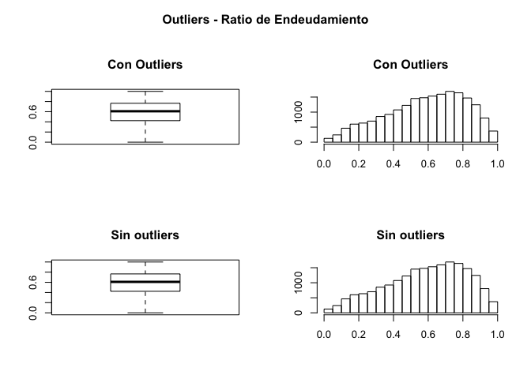

```r
outliers.data(data.panel.a, data.panel.a$ratio_endeudamiento, titulo = "Outliers - Ratio de Endeudamiento")
```

Observamos que la funcion que he creado funciona correctament, y en el ratio de endeudamiento no hay Outliers, como se muestra los gráficos no hay varianción. Es lógico teniendo en cuenta que ya eliminamos los valores superiores a 1.

#### Outliers en el ratio_rotación

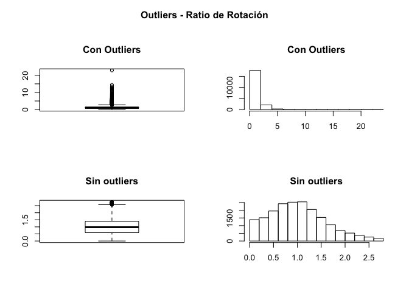

```r
outliers.data(data.panel.a, data.panel.a$ratio_rotacion, titulo = "Outliers - Ratio de Rotación")
```

#### Outliers en el ratio_tesoreria

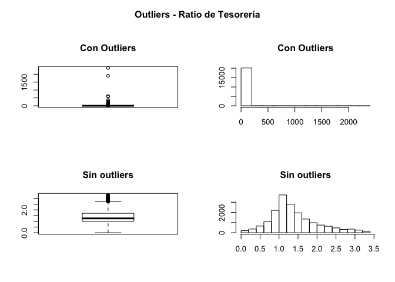

```r
outliers.data(data.panel.a, data.panel.a$ratio_tesoreria, titulo = "Outliers - Ratio de Tesorería")
```

#### Outliers en el ROA

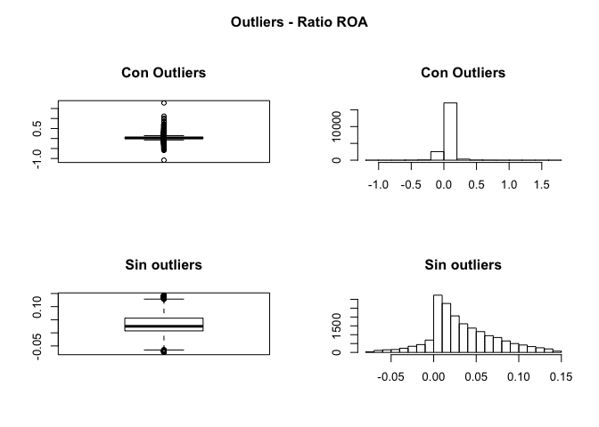

```r
outliers.data(data.panel.a, data.panel.a$roa, titulo = "Outliers - Ratio ROA")
```

#### Outliers en el ROE

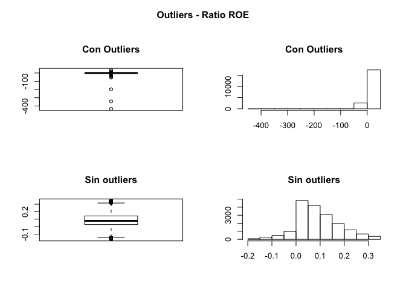

```r
outliers.data(data.panel.a, data.panel.a$roe, titulo = "Outliers - Ratio ROE")
```

**De este modo podemos observar fácilmente que variables necesitan tratamiento, en el siguente paso voy a winsorizar los datos usando los percentiles 99% y 1% de cada datos, ya que el método que he utilizado para visualizar y descartar outliers nos eliminaría muchas observaciones y creo que no conviene ser un poco flexible, ya que hay algunos valores extremos que si que pueden ser posibles en la vida real.**

#### 2. Winzorización de Outliers

```r
## Winsorización: Replazo las observaciones extremas por los valores de los percentiles 99% y 1%
winsorize.data = function(x, q = 0.01){
  quantil_superior <- quantile(x, 1 - q, na.rm = F)
  quantil_inferior <- quantile(x, q, na.rm = F)
  i = which(x >= quantil_superior)
  x[i] = quantil_superior
  j = which(x <= quantil_inferior)
  x[j] = quantil_inferior
  return(x)
}


## Aplico mi función winsorización a mis variables de interés
data.panel.w <- data.panel.a %>% na.omit() %>%
  mutate_at(vars(ratio_rotacion, ratio_tesoreria, roa, roe), funs(winsorize.data)) %>%
  pdata.frame(index = c("nif", "year"))

## algunas pruebas si hay missing values
#anyNA(data.panel.w$default)
#countNA(data.panel.w$default)
#data.panel.w %>% filter(is.na(default))
```

### Especificación del modelo

#### 1. Dividimos los datos en training y testing

```r
data.model <- as_data_frame(data.panel.w)
nID <- length(unique(data.model$nif)) ## genero el número de nif únicos
p = 0.70 ## Separo el datas ser en 70% Training y 30% Testing
set.seed(1234) ## Hacemos que la aletoriedad de la división sea reproducible
## Amplico el sample aleatorio por nif y sin remplazo para mantener muestras independientes
inTrainID <- sample(unique(data$nif), round(nID * p), replace=FALSE)
training <- data.panel.w[data.model$nif %in% inTrainID, ]
testing <- data.panel.w[!data.model$nif %in% inTrainID, ]
training$default <- as.factor(training$default)
testing$default <- as.factor(testing$default)

### realizo alguna pruebas para ver como se han dividido los datos
# levels(training$default)
# levels(testing$default)

## Porcentaje de defaults y no default en cada partición
## En el paned de datos general:
table(data.model$default) / nrow(data.model)
```

```
##
##          0          1
## 0.93437625 0.06562375
```

```r
## En la partición de training:
table(training$default) / nrow(training)
```

```
##
##          0          1
## 0.93414288 0.06585712
```

```r
## En la partición de testing:
table(testing$default) / nrow(testing)
```

```
##
##          0          1
## 0.93467797 0.06532203
```

**Observamos que los datos conservan las proporciones adecuadas en cada partición, tanto para training como para testing. El único problema que veo es que como es lógico los datos no estan balanceados. El 93% de los datos son No Default y el 7% restante son default. Deberiamos balancear los datos para obtener una curva ROC adecuada, porque por probabilidad si apostamos por que no va cometer default y le concedemos el crédito, estarémos prediciendo bien el 93% de los casos en esta muestra, y podriamos llegar a pensar que nuestro modelo predice super bien, con AUC de valores próximos a 1.**

#### 2. Generanción de modelo training

##### Opción A. Resultados sin balancear los datos:

##### Modelo 1 - con todas las variabels

```r
## Voy a asignarle factores al default, para que quede más claro cuando es Default = "Yes" & No Default = "No"
training$default <- factor(training$default, labels = c("No", "Yes"))
testing$default <- factor(testing$default, labels = c("No", "Yes"))
```

```r
## Asignamos número de folds de k-veces cross-validation, de este modelos los estadísticos serán más consisitentes
folds = 10

## Fijamos el parámetro de control, nos aplicará CV, le indicamos que queremos el resumen para las dos categorias
## Además le indicamos que queremos guardar las predicciones - correponderan a las In Sample.
fitControl <- trainControl(method = 'cv',
                           number = folds,
                           classProbs = TRUE,
                           summaryFunction = twoClassSummary,
                           savePrediction = TRUE)

## Preprocesamiento de datos para regularizar

## MODELO LOGÍSTICO 1: con todos los ratios
set.seed(1234) ##para que los datos sean reproducibles
logistic.M1 <- caret::train(default ~ ratio_endeudamiento + ratio_rotacion + ratio_tesoreria + roa
                            + roe, data = training,
                            method = "glm", family = binomial,
                            metric = "ROC", ## Le indico que quiero el area debajo la curva ROC
                            trControl = fitControl)
summary(logistic.M1)
```

```
##
## Call:
## NULL
##
## Deviance Residuals:
##     Min       1Q   Median       3Q      Max
## -0.6929  -0.3926  -0.3609  -0.3180   2.8347
##
## Coefficients:
##                     Estimate Std. Error z value Pr(>|z|)
## (Intercept)         -2.87386    0.18028 -15.941  < 2e-16 ***
## ratio_endeudamiento  0.57295    0.22037   2.600  0.00932 **
## ratio_rotacion       0.02996    0.04647   0.645  0.51911
## ratio_tesoreria     -0.01444    0.03023  -0.478  0.63285
## roa                 -3.03269    1.27473  -2.379  0.01736 *
## roe                 -0.69110    0.28709  -2.407  0.01607 *
## ---
## Signif. codes:  0 '***' 0.001 '**' 0.01 '*' 0.05 '.' 0.1 ' ' 1
##
## (Dispersion parameter for binomial family taken to be 1)
##
##     Null deviance: 5478.3  on 11281  degrees of freedom
## Residual deviance: 5394.8  on 11276  degrees of freedom
## AIC: 5406.8
##
## Number of Fisher Scoring iterations: 5
```

##### Modelo 2 - Prescindiendo de las variables no significativos. (elinino una en cada paso)

```r
## MODELO LOGÍSTICO 2: Elinimando variables no significativas paso a paso
set.seed(1234) ##para que los datos sean reproducibles
logistic.M2 <- caret::train(default ~ ratio_endeudamiento + roa + roe,
                            data = training,
                            method = "glm", family = binomial,
                            metric = "ROC", ## Le indico que quiero el area debajo la curva ROC
                            trControl = fitControl)
summary(logistic.M2)
```

```
##
## Call:
## NULL
##
## Deviance Residuals:
##     Min       1Q   Median       3Q      Max
## -0.6845  -0.3925  -0.3602  -0.3182   2.8266
##
## Coefficients:
##                     Estimate Std. Error z value Pr(>|z|)
## (Intercept)          -2.9126     0.1344 -21.667  < 2e-16 ***
## ratio_endeudamiento   0.6485     0.1911   3.393  0.00069 ***
## roa                  -2.9476     1.2659  -2.328  0.01989 *
## roe                  -0.6821     0.2861  -2.384  0.01713 *
## ---
## Signif. codes:  0 '***' 0.001 '**' 0.01 '*' 0.05 '.' 0.1 ' ' 1
##
## (Dispersion parameter for binomial family taken to be 1)
##
##     Null deviance: 5478.3  on 11281  degrees of freedom
## Residual deviance: 5395.5  on 11278  degrees of freedom
## AIC: 5403.5
##
## Number of Fisher Scoring iterations: 5
```

**El modelo obtenido es el siguiente:**

*default ~ ratio_endeudamiento + roa + roe*

### Pasamos a obtener los valores de las métricas

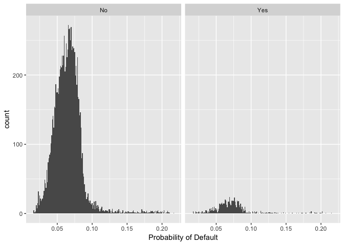

```r
### Classificación de las probabilidades - Modelo Lógistico ### Datos TRAIN ###
class.train <- data.frame(obs = logistic.M2$pred$obs,
                         Yes = c(logistic.M2$pred$Yes))

## Como los datos no estan balanceados el punto de corte de probabilidad es muy bajo
class.train$No <- 1 - class.train$Yes
class.train$pred <- factor(ifelse(class.train$Yes >= 0.05, "Yes", "No"))

### Probabilidades del Modelo Logístico ### Datos TRAIN ###
ggplot(class.train, aes(x = Yes)) +
  geom_histogram(binwidth = .001) +
  facet_wrap(~ obs) +
  xlab("Probability of Default")
```

Observamos que el modelo no parece que sea el más idoneo para clasificar, pero si somo el banco y nos preocupa el default podemos fijar el corte a partir del 0.05 de probailidad de eso modo clasificaremos bien la mayoria de que si que son default.

#### Matriz de confusión

```r
### Métricas para el modelo lógistico ### Datos TRAIN ###
confusionMatrix(data = class.train$pred, reference = class.train$obs, mode = "everything", positive = "Yes")
```

```
## Confusion Matrix and Statistics
##
##           Reference
## Prediction   No  Yes
##        No  2189  107
##        Yes 8350  636
##
##                Accuracy : 0.2504
##                  95% CI : (0.2424, 0.2585)
##     No Information Rate : 0.9341
##     P-Value [Acc > NIR] : 1
##
##                   Kappa : 0.0103
##  Mcnemar's Test P-Value : <2e-16
##
##             Sensitivity : 0.85599
##             Specificity : 0.20770
##          Pos Pred Value : 0.07078
##          Neg Pred Value : 0.95340
##               Precision : 0.07078
##                  Recall : 0.85599
##                      F1 : 0.13074
##              Prevalence : 0.06586
##          Detection Rate : 0.05637
##    Detection Prevalence : 0.79649
##       Balanced Accuracy : 0.53185
##
##        'Positive' Class : Yes
##
```

#### ROC

```r
rocurve_M2 <- roc.curve(scores.class0 = class.train$pred, scores.class1 = class.train$obs, curve = T)
##Obtenemos un area bajos la curva
rocurve_M2
```

```
##
##   ROC curve
##
##     Area under curve:
##      0.8653164
##
##     Curve for scores from  1  to  2
##     ( can be plotted with plot(x) )
```

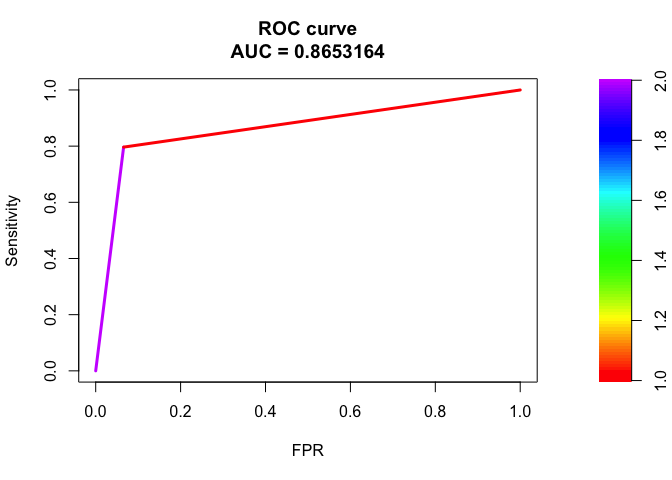

```r
##Ploteamos el ROC
plot(rocurve_M2)
```

**Observamos que el área bajo la curba es es bastante óptimom, pero es una falsa apariencia, ya que si ponemos la linea base en que si classificamos correcatamente 93% de las empresas si a todas le asignamos No Default, de hecho lo interesante en el gráfico es el primer tramo donde asciende rápidamente y a partir del 0.1% de probailidad ya empiezas a asignar a todos No Default.**

#### Valoración del modelo Out of Sample:

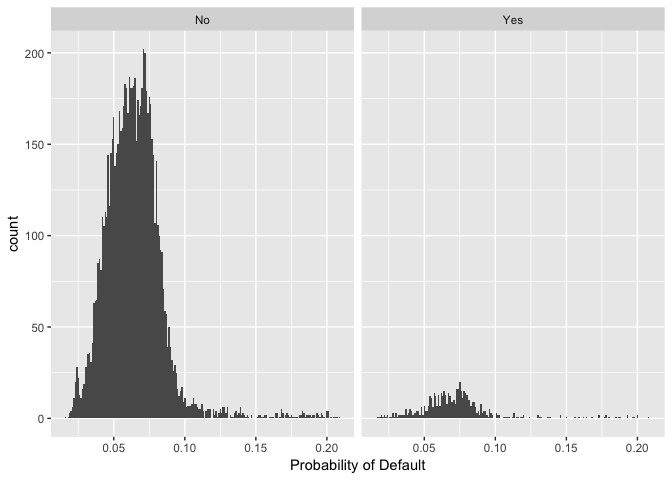

```r
### Predicción de los datos sobre los datos testing Modelo lógistico:
pred.logistic.M2 <- predict(logistic.M2, newdata = testing, type = "prob")

### Classificación de las probabilidades - Modelo Lógistico ### Datos TEST ###
class.test <- data.frame(obs = testing$default,
                         Yes = c(pred.logistic.M2$Yes))

class.test$No <- 1 - class.test$Yes
class.test$pred <- factor(ifelse(class.test$Yes >= 0.05, "Yes", "No"))

### Probabilidades del Modelo Logístico ### Datos TEST ###
ggplot(class.test, aes(x = Yes)) +
  geom_histogram(binwidth = .001) +
  facet_wrap(~ obs) +
  xlab("Probability of Default")
```

**Observamos que las distribuciones de probabilidad son muy parecidad con el modelo Out Sample, y se sigue produciendo ese problema en el cual no diferenciamos bien a los Default de los No Defaults**

```r
### Métricas para el modelo lógistico ### Datos TEST ###
confusionMatrix(data = class.test$pred, reference = class.test$obs, mode = "everything", positive = "Yes")
```

```
## Confusion Matrix and Statistics
##
##           Reference
## Prediction   No  Yes
##        No  1870   79
##        Yes 6286  491
##
##                Accuracy : 0.2706
##                  95% CI : (0.2613, 0.28)
##     No Information Rate : 0.9347
##     P-Value [Acc > NIR] : 1
##
##                   Kappa : 0.015
##  Mcnemar's Test P-Value : <2e-16
##
##             Sensitivity : 0.86140
##             Specificity : 0.22928
##          Pos Pred Value : 0.07245
##          Neg Pred Value : 0.95947
##               Precision : 0.07245
##                  Recall : 0.86140
##                      F1 : 0.13366
##              Prevalence : 0.06532
##          Detection Rate : 0.05627
##    Detection Prevalence : 0.77664
##       Balanced Accuracy : 0.54534
##
##        'Positive' Class : Yes
##
```

```r
rocurve_M2_test <- roc.curve(scores.class0 = class.test$pred, scores.class1 = class.test$obs, curve = T)
##Obtenemos un area bajos la curva
rocurve_M2_test
```

```
##
##   ROC curve
##
##     Area under curve:
##      0.8556612
##
##     Curve for scores from  1  to  2
##     ( can be plotted with plot(x) )
```

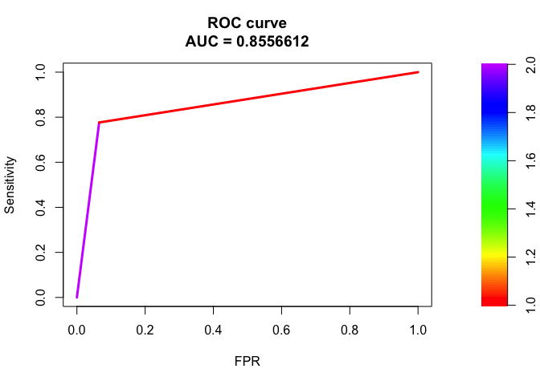

```r
##Ploteamos el ROC
plot(rocurve_M2_test)
```

**El Área debajo de la curva obtenido para los datos de testing es muy parecido al de los datos de training. Cabe decir que aun así no es un buen modelo predictivo ya que no conseguimos diferenciar bien a los buenos de los malos, ya que la funciones de probabilidad que asígna a cada individuo se solpan mucho tanto en los datos de entrenamiento como en los datos de test. He procurado poner un punto de corte bastante bajo para así detectar mejor a los malos, pero esto generá un gran coste de oportunidad no clasificando bien a muchas empresas que si que son buenas.**

#### Z-Score de Altman

```r
Zscore <- data.panel.p %>%
  group_by(nif, year) %>%
  mutate(X1 = (activo_circ - pasivo_liq)/total_activo, X2 = rdo_ejercicio/total_activo, X3 = (bai + intereses)/total_activo, X4 = 1, X5 = ig_explo / total_activo) %>%
  mutate(ZScore.value = 1.2*X1 + 1.4*X2 + 3.3*X3 + 0.6*X4 + 1.0*X5) %>%
  select(nif, year, X1, X2, X3, X4, X5, ZScore.value, default) %>%
  pdata.frame(replace.non.finite = T) %>%
  mutate(Zdefault = if_else(ZScore.value < 1.8, true = 1, false = 0)) %>%
  filter(year != 2017) %>% na.omit()

## Obtenemos la matriz de confusión donde los datos de referencia son los default de la primera parte, y la predicción
## son los datos del ZScore de Altman.
confusionMatrix(as.factor(Zscore$Zdefault), reference = as.factor(Zscore$default), positive = "1", mode = "everything")
```

```
## Confusion Matrix and Statistics
##
##           Reference
## Prediction     0     1
##          0 13299   785
##          1  6716   504
##
##                Accuracy : 0.6479
##                  95% CI : (0.6414, 0.6543)
##     No Information Rate : 0.9395
##     P-Value [Acc > NIR] : 1
##
##                   Kappa : 0.0176
##  Mcnemar's Test P-Value : <2e-16
##
##             Sensitivity : 0.39100
##             Specificity : 0.66445
##          Pos Pred Value : 0.06981
##          Neg Pred Value : 0.94426
##               Precision : 0.06981
##                  Recall : 0.39100
##                      F1 : 0.11846
##              Prevalence : 0.06051
##          Detection Rate : 0.02366
##    Detection Prevalence : 0.33890
##       Balanced Accuracy : 0.52773
##
##        'Positive' Class : 1
##
```

**El modelo ZScore de Altman no ofrece mejores resultados que el modelo logistico que propongo al principio.**

## Roc Curve para Zscore de Altman

```r
rocurve_zscore <- roc.curve(scores.class0 = Zscore$Zdefault, scores.class1 = Zscore$default, curve = T)
##Obtenemos un area bajos la curva
rocurve_zscore
```

```
##
##   ROC curve
##
##     Area under curve:
##      0.6391992
##
##     Curve for scores from  0  to  1
##     ( can be plotted with plot(x) )
```

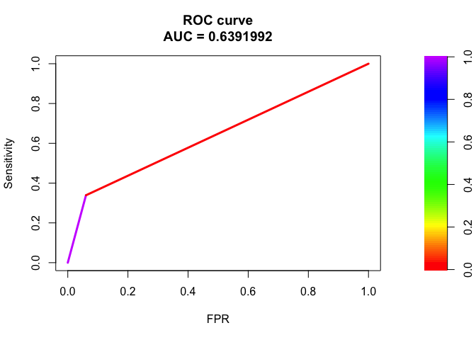

```r
##Ploteamos el ROC
plot(rocurve_zscore)
```

**Obtenemos un área debajo de la curva de 63.9% muy por debajo de los 85% que ofrece nuestro modelo lógistico, el desempeño de la ZScore de Altman no es nada bueno.**

#### 3. Predicción sobre una nueva empresa, usando nuestro modelo “logistic.M2”

```r
## Generamos los datos de la empresa propuesta
empresa.zxs <- data.frame(empresa.zxs=c(ratio_endeudamiento = 4117.194 / 15039.12,
         roa = 1122.191 / 15039.12,
         roe = 1122.191 / 10921.92))
empresa.zxs <- t(empresa.zxs)
### Predicción de los datos sobre los datos de la empresa ZXS Modelo lógistico:
pred.logistic.M2.zxs <- predict(logistic.M2, newdata = empresa.zxs, type = "prob")
pred.logistic.M2.zxs
```

```
##                    No        Yes
## empresa.zxs 0.9536962 0.04630384
```

**Si mantemos el punto de corte que he propuesto en el ejercicio anterior, como entidad bancaria si que le concederia un crédito ya que su probabilidad de default es menor que 0.05.**